# Customer segmentation and market basket analysis

- Customer segmentation: is the problem of uncovering information about a firm’s customer base, based on their interactions with the business.

Customer segmentation is similarly the process of dividing an organization’s customer bases into different sections or segments based on various customer attributes. These could be their buying behavior, their demographic information, their geographic information, their psychographic attributes, etc. Identified patterns play a crucial role in determining the company direction towards addressing the various segments and reap maximum profit

Customer segmentation help us to

```
- Target marketing
- Optimal product placement
- identify untapped segments
```

- Market basket analysis: MBA is a method to gain insights into granular behavior of customers. Even the customer will be unaware of such biases or trends in their purchasing behavior

## Data

Data from: http://archive.ics.uci.edu/ml/datasets/online+retail

It contains all the transactions occurring between 01/12/2010 and 09/12/2011 for a UK-based and registered non-store online retail. The company sells unique all-occasion gift items and a lot of customers of the organization are wholesalers.

# Objectives

- In this analysis, we would like to identify customer segments by analyzing the characteristics of the clusters from data

# Load Dependencies and Configuration Settings

```python
import pandas as pd
import datetime
import math
import numpy as np
import matplotlib.pyplot as plt
import matplotlib.mlab as mlab
import seaborn as sns
from scipy.stats import norm

from sklearn.cluster import KMeans
from sklearn.metrics import silhouette_samples, silhouette_score
import matplotlib.cm as cm
from mpl_toolkits.mplot3d import Axes3D
from sklearn import preprocessing
import math

from plotly import tools
import plotly.offline as py
py.init_notebook_mode(connected=True)
import plotly.graph_objs as go
import plotly.figure_factory as ff

import warnings
warnings.filterwarnings('ignore')

sns.set_style('whitegrid')
sns.set_context('talk')
params = {'legend.fontsize': 'x-large',
          'figure.figsize': (30, 10),
          'axes.labelsize': 'x-large',
          'axes.titlesize':'x-large',
          'xtick.labelsize':'x-large',
          'ytick.labelsize':'x-large'}

plt.rcParams.update(params)


%matplotlib inline
```

# EDA : Load and View the Dataset

```python
cs_df = pd.read_excel('OnlineRetail.xlsx')
```

```python
cs_df.head(3)
```

|  | InvoiceNo | StockCode | Description | Quantity | InvoiceDate | UnitPrice | CustomerID | Country |
| --- | --- | --- | --- | --- | --- | --- | --- | --- |
| 0 | 536365 | 85123A | WHITE HANGING HEART T-LIGHT HOLDER | 6 | 2010-12-01 08:26:00 | 2.55 | 17850.0 | United Kingdom |
| 1 | 536365 | 71053 | WHITE METAL LANTERN | 6 | 2010-12-01 08:26:00 | 3.39 | 17850.0 | United Kingdom |
| 2 | 536365 | 84406B | CREAM CUPID HEARTS COAT HANGER | 8 | 2010-12-01 08:26:00 | 2.75 | 17850.0 | United Kingdom |

Columns are

- InvoiceNo: A unique identifier for the invoice. An invoice number shared acrossrows means that those transactions were performed in a single invoice (multiple purchases).
- StockCode: Identifier for items contained in an invoice.
- Description: Textual description of each of the stock item.
- Quantity: The quantity of the item purchased.
- InvoiceDate: Date of purchase.
- UnitPrice: Value of each item.
- CustomerID: Identifier for customer making the purchase.
- Country: Country of customer.

```python
#Transactions size
cs_df.shape
```

```
(541909, 8)
```

### Top sales by country

```python
cs_df.Country.value_counts().reset_index().head(n=10)
```

|  | index | Country |
| --- | --- | --- |
| 0 | United Kingdom | 495478 |
| 1 | Germany | 9495 |
| 2 | France | 8557 |
| 3 | EIRE | 8196 |
| 4 | Spain | 2533 |
| 5 | Netherlands | 2371 |
| 6 | Belgium | 2069 |
| 7 | Switzerland | 2002 |
| 8 | Portugal | 1519 |
| 9 | Australia | 1259 |

```python
count_geo = cs_df.Country.value_counts()
data = [dict(
        type = 'choropleth',
        locations = count_geo.index,
        locationmode = 'country names',
        z = count_geo.values,
        text = count_geo.index,
        colorscale = [[0,"rgb(5, 10, 172)"],[0.35,"rgb(40, 60, 190)"],
                      [0.5,"rgb(70, 100, 245)"],
            [0.6,"rgb(90, 120, 245)"],[0.7,"rgb(106, 137, 247)"],
                      [1,"rgb(220, 220, 220)"]],
        autocolorscale = False,
        reversescale = True,
        marker = dict(
            line = dict (
                color = 'rgb(180,180,180)',
                width = 0.5
            ) ),
        colorbar = dict( title='Order counts',
            autotick = False,
            tickprefix = ''),
      ) ]

layout = dict(
    title = 'Top shipments are to these  countries',
    geo = dict(
        showframe = False,
        showcoastlines = True,
        projection = dict(
            type = 'Mercator'
        )
    )
)

fig = dict(data=data, layout=layout)
py.iplot(fig, validate=False)
```

[interactive chart not shown]

Bulk of ordering is taking place in UK (home country)

### Top Customers contributing to 10% of total Sales

Number of customers

```python
cs_df.CustomerID.unique().shape
```

```
(4373,)
```

```python
(cs_df.CustomerID.value_counts()/sum(cs_df.CustomerID.value_counts())*100).head(n=13).cumsum()
```

```
17841.0    1.962249
14911.0    3.413228
14096.0    4.673708
12748.0    5.814728
14606.0    6.498553
15311.0    7.110850
14646.0    7.623350
13089.0    8.079807
13263.0    8.492020
14298.0    8.895138
15039.0    9.265809
14156.0    9.614850
18118.0    9.930462
Name: CustomerID, dtype: float64
```

A total of 4373 customers are there, however, top 10% of the sales are done by 13 customers. Note that we have both wholesale and retail customers here, so this is not surprising

### Analyzing Data Quality Issues

```python
pd.DataFrame([{'customers': len(cs_df['CustomerID'].value_counts()),
               'transactions': len(cs_df['InvoiceNo'].value_counts()),
               'description': len(cs_df['Description'].value_counts()),
               'StockCode': len(cs_df['StockCode'].value_counts()),

              }], columns = ['transactions', 'customers', 'description','StockCode'], index = ['quantity'])
```

|  | transactions | customers | description | StockCode |
| --- | --- | --- | --- | --- |
| quantity | 25900 | 4372 | 4223 | 4070 |

There are 4372 users that bought 4070 (represented by stockcode) different products. The total number of transactions carried out is 25900. The descriptions of items seems to be more than the number of stock code displayed, so there must be some stock code which have more than one description.

Let us investigate this further

```python
cs_df.dtypes
```

```
InvoiceNo              object
StockCode              object
Description            object
Quantity                int64
InvoiceDate    datetime64[ns]
UnitPrice             float64
CustomerID            float64
Country                object
dtype: object
```

```python
cat_des_df = cs_df.groupby(["StockCode","Description"]).count().reset_index()
```

Stockcode which have more than one description

```python
cat_des_df.StockCode.value_counts()[cat_des_df.StockCode.value_counts()>1].reset_index().head()
```

|  | index | StockCode |
| --- | --- | --- |
| 0 | 20713 | 8 |
| 1 | 23084 | 7 |
| 2 | 85175 | 6 |
| 3 | 21830 | 6 |
| 4 | 23343 | 5 |

Example of one such stockcode

```python
cs_df[cs_df['StockCode'] == cat_des_df.StockCode.value_counts()[cat_des_df.StockCode.value_counts()>1]
      .reset_index()['index'][5]]['Description'].unique()
```

```
array(['MISTLETOE HEART WREATH CREAM', 'MISELTOE HEART WREATH WHITE',
       'MISELTOE HEART WREATH CREAM', '?', 'had been put aside', nan],
      dtype=object)
```

Looks like same item has some spelling mistakes and hence result in multiple descriptions

```python
cs_df['invdatetime'] = pd.to_datetime(cs_df.InvoiceDate)
```

```python
cs_df.Quantity.describe()
```

```
count    541909.000000
mean          9.552250
std         218.081158
min      -80995.000000
25%           1.000000
50%           3.000000
75%          10.000000
max       80995.000000
Name: Quantity, dtype: float64
```

```python
cs_df.UnitPrice.describe()
```

```
count    541909.000000
mean          4.611114
std          96.759853
min      -11062.060000
25%           1.250000
50%           2.080000
75%           4.130000
max       38970.000000
Name: UnitPrice, dtype: float64
```

The preceding outputs shows that both of these attributes have negative values, which may indicate that we may have some return transactions

## Data Cleaning

In this particular analysis, we exclusively focus on UK customers.

```python
# Seperate data for one geography
cs_df_uk = cs_df[cs_df.Country == 'United Kingdom']

# Seperate attribute for total amount
cs_df_uk['amount'] = cs_df_uk.Quantity*cs_df_uk.UnitPrice

# Remove negative or return transactions
cs_df_uk = cs_df_uk[~(cs_df_uk.amount<0)]

cs_df_uk = cs_df_uk[~(cs_df_uk.CustomerID.isnull())]
cs_df_uk.head(3)
```

|  | InvoiceNo | StockCode | Description | Quantity | InvoiceDate | UnitPrice | CustomerID | Country | invdatetime | amount |
| --- | --- | --- | --- | --- | --- | --- | --- | --- | --- | --- |
| 0 | 536365 | 85123A | WHITE HANGING HEART T-LIGHT HOLDER | 6 | 2010-12-01 08:26:00 | 2.55 | 17850.0 | United Kingdom | 2010-12-01 08:26:00 | 15.30 |
| 1 | 536365 | 71053 | WHITE METAL LANTERN | 6 | 2010-12-01 08:26:00 | 3.39 | 17850.0 | United Kingdom | 2010-12-01 08:26:00 | 20.34 |
| 2 | 536365 | 84406B | CREAM CUPID HEARTS COAT HANGER | 8 | 2010-12-01 08:26:00 | 2.75 | 17850.0 | United Kingdom | 2010-12-01 08:26:00 | 22.00 |

```python
cs_df_uk.shape
```

```
(354345, 10)
```

# RFM model

- Recency: How recently a customer purchased
- Frequency: How frequent the customer’s transactions are
- Monetary value: The dollar value of all the transactions

A combination of these can be used to assign a value to the customer

### Build Recency Feature

```python
#find the last date as reference
cs_df_uk.InvoiceDate.max()
```

```
Timestamp('2011-12-09 12:49:00')
```

```python
cs_df_uk.InvoiceDate.min()
```

```
Timestamp('2010-12-01 08:26:00')
```

```python
#define our reference date as one day after the last transaction in our dataset
reference_date = cs_df_uk.InvoiceDate.max()
reference_date = reference_date + datetime.timedelta(days = 1)
```

```python
cs_df_uk['days_since_last_purchase'] = reference_date - cs_df_uk.InvoiceDate
cs_df_uk['days_since_last_purchase_num'] = cs_df_uk['days_since_last_purchase'].astype('timedelta64[D]')
```

Time period of transactions

```python
customer_history_df = cs_df_uk.groupby("CustomerID").min().reset_index()[['CustomerID', 'days_since_last_purchase_num']]
customer_history_df.rename(columns={'days_since_last_purchase_num':'recency'}, inplace=True)
```

```python
customer_history_df.head()
```

|  | CustomerID | recency |
| --- | --- | --- |
| 0 | 12346.0 | 326.0 |
| 1 | 12747.0 | 2.0 |
| 2 | 12748.0 | 1.0 |
| 3 | 12749.0 | 4.0 |
| 4 | 12820.0 | 3.0 |

```python
customer_history_df.recency.describe()
```

```
count    3921.000000
mean       92.188472
std        99.528995
min         1.000000
25%        18.000000
50%        51.000000
75%       143.000000
max       374.000000
Name: recency, dtype: float64
```

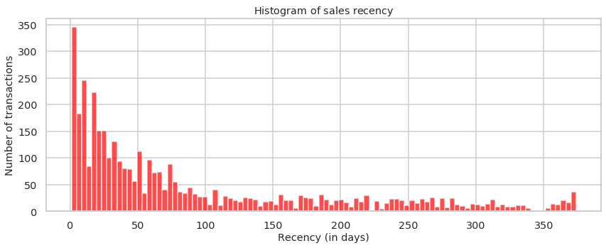

```python
x = customer_history_df.recency
plt.figure(figsize=(14,5))
plt.hist(x, 100, facecolor='red', alpha=0.7)
plt.xlabel('Recency (in days)')
plt.ylabel('Number of transactions')
plt.title(r'$\mathrm{Histogram\ of\ sales\ recency}\ $')
plt.grid(True)
```

It looks like, we have skewed distribution of sales recency with a much higher number of frequent transactions and a fairly uniform number of less recent transactions

### Build Frequency & Monetary value Features

```python
customer_monetary_val = cs_df_uk[['CustomerID', 'amount']].groupby("CustomerID").sum().reset_index()
customer_history_df = customer_history_df.merge(customer_monetary_val, how='outer')
customer_history_df.amount = customer_history_df.amount+0.001 # to avoid future complication with logarithms
customer_freq = cs_df_uk[['CustomerID', 'amount']].groupby("CustomerID").count().reset_index()
customer_freq.rename(columns={'amount':'frequency'},inplace=True)
customer_history_df = customer_history_df.merge(customer_freq, how='outer')
```

Remove returns so that we only have purchases of a customer

```python
customer_history_df.head()
```

|  | CustomerID | recency | amount | frequency |
| --- | --- | --- | --- | --- |
| 0 | 12346.0 | 326.0 | 77183.601 | 1 |
| 1 | 12747.0 | 2.0 | 4196.011 | 103 |
| 2 | 12748.0 | 1.0 | 33719.731 | 4596 |
| 3 | 12749.0 | 4.0 | 4090.881 | 199 |
| 4 | 12820.0 | 3.0 | 942.341 | 59 |

### standardize data

```python
#log scale addresses the huge range of values each variable
customer_history_df['recency_log'] = customer_history_df['recency'].apply(math.log)
customer_history_df['frequency_log'] = customer_history_df['frequency'].apply(math.log)
customer_history_df['amount_log'] = customer_history_df['amount'].apply(math.log)
feature_vector = ['amount_log', 'recency_log','frequency_log']

X_subset = customer_history_df[feature_vector].as_matrix()
#clustering algo needs standardization

scaler = preprocessing.StandardScaler().fit(X_subset)
X_scaled = scaler.transform(X_subset)
```

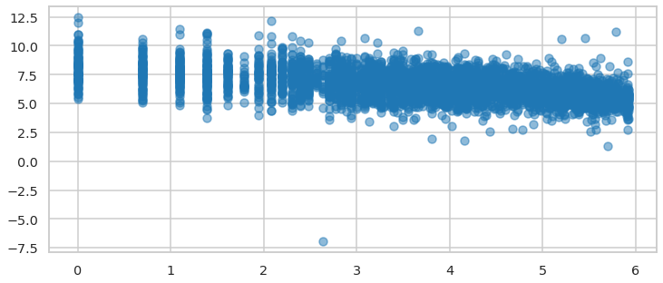

```python
#visualizing Recency vs Monetary Value (scaled)
plt.figure(figsize=(12,5))
plt.scatter(customer_history_df.recency_log, customer_history_df.amount_log, alpha=0.5)
```

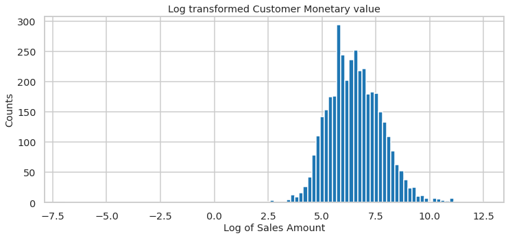

```python
# visualizing Monetary Value distribution (scaled)
plt.figure(figsize=(12,5))
x = customer_history_df.amount_log
plt.hist(x, 100)
plt.xlabel('Log of Sales Amount')
plt.ylabel('Counts')
plt.title('Log transformed Customer Monetary value')
plt.grid(True)
```

```python
customer_history_df.head()
```

|  | CustomerID | recency | amount | frequency | recency_log | frequency_log | amount_log |
| --- | --- | --- | --- | --- | --- | --- | --- |
| 0 | 12346.0 | 326.0 | 77183.601 | 1 | 5.786897 | 0.000000 | 11.253942 |
| 1 | 12747.0 | 2.0 | 4196.011 | 103 | 0.693147 | 4.634729 | 8.341890 |
| 2 | 12748.0 | 1.0 | 33719.731 | 4596 | 0.000000 | 8.432942 | 10.425838 |
| 3 | 12749.0 | 4.0 | 4090.881 | 199 | 1.386294 | 5.293305 | 8.316516 |
| 4 | 12820.0 | 3.0 | 942.341 | 59 | 1.098612 | 4.077537 | 6.848367 |

```python
xs =customer_history_df.recency_log
ys = customer_history_df.frequency_log
zs = customer_history_df.amount_log


fig = go.Figure(data=data,layout=graph_layout)
#fig.show()
py.iplot(fig)
```

[interactive chart not shown]

- People who buy with a higher frequency and more recency tend to spend more!

# Analyze Customer Segments with Clustering

Use K-means clustering algorithm for finding out clusters (or segments in our data).

```
CPU times: user 4.99 s, sys: 996 ms, total: 5.98 s
Wall time: 2.24 s
```

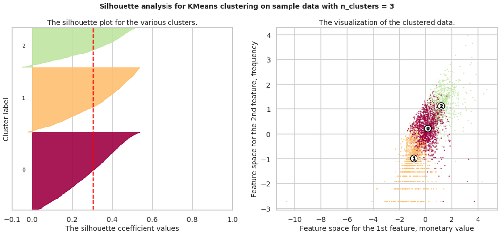

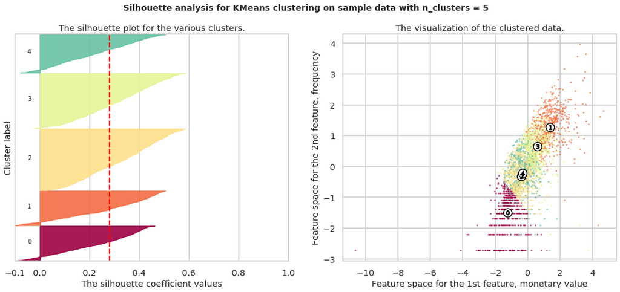

```python
%%time
#https://scikit-learn.org/stable/auto_examples/cluster/plot_kmeans_silhouette_analysis.html
X = X_scaled
cluster_centers = dict()

for n_clusters in range(3,6,2):
    fig, (ax1, ax2) = plt.subplots(1, 2)
    fig.set_size_inches(18, 7)
    ax1.set_xlim([-0.1, 1])
    ax1.set_ylim([0, len(X) + (n_clusters + 1) * 10])

    clusterer = KMeans(n_clusters=n_clusters, random_state=42)
    cluster_labels = clusterer.fit_predict(X)

    silhouette_avg = silhouette_score(X, cluster_labels)
    cluster_centers.update({n_clusters :{
                                        'cluster_center':clusterer.cluster_centers_,
                                        'silhouette_score':silhouette_avg,
                                        'labels':cluster_labels}
                           })

    sample_silhouette_values = silhouette_samples(X, cluster_labels)
    y_lower = 10
    for i in range(n_clusters):
        ith_cluster_silhouette_values = \
            sample_silhouette_values[cluster_labels == i]

        ith_cluster_silhouette_values.sort()

        size_cluster_i = ith_cluster_silhouette_values.shape[0]
        y_upper = y_lower + size_cluster_i

        color = cm.Spectral(float(i) / n_clusters)
        ax1.fill_betweenx(np.arange(y_lower, y_upper),
                          0, ith_cluster_silhouette_values,
                          facecolor=color, edgecolor=color, alpha=0.9)

        ax1.text(-0.05, y_lower + 0.5 * size_cluster_i, str(i))
        y_lower = y_upper + 10  # 10 for the 0 samples

    ax1.set_title("The silhouette plot for the various clusters.")
    ax1.set_xlabel("The silhouette coefficient values")
    ax1.set_ylabel("Cluster label")
    ax1.axvline(x=silhouette_avg, color="red", linestyle="--")
    ax1.set_yticks([])
    ax1.set_xticks([-0.1, 0, 0.2, 0.4, 0.6, 0.8, 1])
    colors = cm.Spectral(cluster_labels.astype(float) / n_clusters)
    feature1 = 0
    feature2 = 2
    ax2.scatter(X[:, feature1], X[:, feature2], marker='.', s=30, lw=0, alpha=0.7,
                c=colors, edgecolor='k')

    centers = clusterer.cluster_centers_
    ax2.scatter(centers[:, feature1], centers[:, feature2], marker='o',
                c="white", alpha=1, s=200, edgecolor='k')
    for i, c in enumerate(centers):
        ax2.scatter(c[feature1], c[feature2], marker='$%d$' % i, alpha=1,
                    s=50, edgecolor='k')
    ax2.set_title("The visualization of the clustered data.")
    ax2.set_xlabel("Feature space for the 1st feature, monetary value")
    ax2.set_ylabel("Feature space for the 2nd feature, frequency")
    plt.suptitle(("Silhouette analysis for KMeans clustering on sample data "
                  "with n_clusters = %d" % n_clusters),
                 fontsize=14, fontweight='bold')
    #plt.show()
```

Consider the three-cluster configuration

- Clusters with stark differences in the Monetary value of the customer.
- Cluster 2 is the cluster of high value customer who shops frequently and is certainly an important segment for each business

```python
#convert normal values from the log and scaled version we used for clustering
for i in range(3,6,2):
    print("==For {} number of clusters".format(i))
    cent_transformed = scaler.inverse_transform(cluster_centers[i]['cluster_center'])
    print(pd.DataFrame(np.exp(cent_transformed),columns=feature_vector))
    print("\t Silhouette score for cluster {} is {}". format(i, cluster_centers[i]['silhouette_score']))
    print()
```

```
==For 3 number of clusters
    amount_log  recency_log  frequency_log
0   831.539058    44.169587      53.320314
1   220.562140   122.302401      10.607927
2  3158.748880     7.396805     177.087308
	 Silhouette score for cluster 3 is 0.3035822004477785

==For 5 number of clusters
    amount_log  recency_log  frequency_log
0   142.409964   128.470523       5.178031
1  3871.358025     5.629258     213.277656
2   412.043518   139.782842      25.763915
3  1506.208904    46.286816      92.567354
4   457.028698    13.670415      28.798090
	 Silhouette score for cluster 5 is 0.2796754238143549
```

A higher value of silhouette coefficient generally means that the clustering model is leading to clusters that are dense and well separated and distinguishable from each other. Lower scores indicate overlapping clusters. Silhouette score matrix suggests three cluster segments are optimal

## Assign Cluster Labels

```python
labels = cluster_centers[5]['labels']
customer_history_df['num_cluster5_labels'] = labels
labels = cluster_centers[3]['labels']
customer_history_df['num_cluster3_labels'] = labels
```

```python
customer_history_df.head()
```

|  | CustomerID | recency | amount | frequency | recency_log | frequency_log | amount_log | num_cluster5_labels | num_cluster3_labels |
| --- | --- | --- | --- | --- | --- | --- | --- | --- | --- |
| 0 | 12346.0 | 326.0 | 77183.601 | 1 | 5.786897 | 0.000000 | 11.253942 | 3 | 0 |
| 1 | 12747.0 | 2.0 | 4196.011 | 103 | 0.693147 | 4.634729 | 8.341890 | 1 | 2 |
| 2 | 12748.0 | 1.0 | 33719.731 | 4596 | 0.000000 | 8.432942 | 10.425838 | 1 | 2 |
| 3 | 12749.0 | 4.0 | 4090.881 | 199 | 1.386294 | 5.293305 | 8.316516 | 1 | 2 |
| 4 | 12820.0 | 3.0 | 942.341 | 59 | 1.098612 | 4.077537 | 6.848367 | 4 | 2 |

## Visualize Segments

### 3 cluster

```python
x_data = ['Cluster 0','Cluster 1','Cluster 2']
cutoff_quantile = 100
field_to_plot = 'recency'
y0 = customer_history_df[customer_history_df['num_cluster3_labels']==0][field_to_plot].values
y0 = y0[y0<np.percentile(y0, cutoff_quantile)]
y1 = customer_history_df[customer_history_df['num_cluster3_labels']==1][field_to_plot].values
y1 = y1[y1<np.percentile(y1, cutoff_quantile)]
y2 = customer_history_df[customer_history_df['num_cluster3_labels']==2][field_to_plot].values
y2 = y2[y2<np.percentile(y2, cutoff_quantile)]

y_data = [y0,y1,y2]

colors = ['rgba(93, 164, 214, 0.5)', 'rgba(255, 144, 14, 0.5)', 'rgba(44, 160, 101, 0.5)', 'rgba(255, 65, 54, 0.5)', 'rgba(207, 114, 255, 0.5)', 'rgba(127, 96, 0, 0.5)']
traces = []

for xd, yd, cls in zip(x_data, y_data, colors):
        traces.append(go.Box(
            y=yd,
            name=xd,
            boxpoints=False,
            jitter=0.5,
            whiskerwidth=0.2,
            fillcolor=cls,
            marker=dict(
                size=2,
            ),
            line=dict(width=1),
        ))

layout = go.Layout(
    title='Difference in sales {} from cluster to cluster'.format(field_to_plot),
    yaxis=dict(
        autorange=True,
        showgrid=True,
        zeroline=True,
        dtick=50,
        gridcolor='black',
        gridwidth=0.1,
        zerolinecolor='rgb(255, 255, 255)',
        zerolinewidth=2,
        title_text="Sales recency(days)",
    ),
    margin=dict(
        l=40,
        r=30,
        b=80,
        t=100,
    ),
    paper_bgcolor='lightgrey',
    plot_bgcolor='white',
    showlegend=False
)

fig = go.Figure(data=traces, layout=layout)
py.offline.iplot(fig)
```

[interactive chart not shown]

```python
x_data = ['Cluster 0','Cluster 1','Cluster 2']
cutoff_quantile = 80
field_to_plot = 'amount'
y0 = customer_history_df[customer_history_df['num_cluster3_labels']==0][field_to_plot].values
y0 = y0[y0<np.percentile(y0, cutoff_quantile)]
y1 = customer_history_df[customer_history_df['num_cluster3_labels']==1][field_to_plot].values
y1 = y1[y1<np.percentile(y1, cutoff_quantile)]
y2 = customer_history_df[customer_history_df['num_cluster3_labels']==2][field_to_plot].values
y2 = y2[y2<np.percentile(y2, cutoff_quantile)]

y_data = [y0,y1,y2]

colors = ['rgba(93, 164, 214, 0.5)', 'rgba(255, 144, 14, 0.5)', 'rgba(44, 160, 101, 0.5)', 'rgba(255, 65, 54, 0.5)', 'rgba(207, 114, 255, 0.5)', 'rgba(127, 96, 0, 0.5)']
traces = []

for xd, yd, cls in zip(x_data, y_data, colors):
        traces.append(go.Box(
            y=yd,
            name=xd,
            boxpoints=False,
            jitter=0.5,
            whiskerwidth=0.2,
            fillcolor=cls,
            marker=dict(
                size=2,
            ),
            line=dict(width=1),
        ))

layout = go.Layout(
    title='Difference in sales {} from cluster to cluster'.format(field_to_plot),
    yaxis=dict(
        dtick=1000,
        title_text="Sales amount",
    ),

    paper_bgcolor='lightgrey',
)

fig = go.Figure(data=traces, layout=layout)
py.offline.iplot(fig)
```

[interactive chart not shown]

We can see that the cluster 2 have a higher average sales amount, thus being the highest spenders.

```python
x_data = ['Cluster 0','Cluster 1','Cluster 2']
cutoff_quantile = 90
field_to_plot = 'frequency'
y0 = customer_history_df[customer_history_df['num_cluster3_labels']==0][field_to_plot].values
y0 = y0[y0<np.percentile(y0, cutoff_quantile)]
y1 = customer_history_df[customer_history_df['num_cluster3_labels']==1][field_to_plot].values
y1 = y1[y1<np.percentile(y1, cutoff_quantile)]
y2 = customer_history_df[customer_history_df['num_cluster3_labels']==2][field_to_plot].values
y2 = y2[y2<np.percentile(y2, cutoff_quantile)]

y_data = [y0,y1,y2]

colors = ['rgba(93, 164, 214, 0.5)', 'rgba(255, 144, 14, 0.5)', 'rgba(44, 160, 101, 0.5)', 'rgba(255, 65, 54, 0.5)', 'rgba(207, 114, 255, 0.5)', 'rgba(127, 96, 0, 0.5)']
traces = []

for xd, yd, cls in zip(x_data, y_data, colors):
        traces.append(go.Box(
            y=yd,
            name=xd,
            boxpoints=False,
            jitter=0.5,
            whiskerwidth=0.2,
            fillcolor=cls,
            marker=dict(
                size=2,
            ),
            line=dict(width=1),
        ))

layout = go.Layout(
    title='Difference in sales {} from cluster to cluster'.format(field_to_plot),
    yaxis=dict(
        autorange=True,
        showgrid=True,
        zeroline=True,
        dtick=100,
        gridcolor='black',
        gridwidth=0.1,
        zerolinecolor='rgb(255, 255, 255)',
        zerolinewidth=2,
        title_text="Sales frequency",
    ),
    margin=dict(
        l=40,
        r=30,
        b=80,
        t=100,
    ),
    paper_bgcolor='lightgrey',
    plot_bgcolor='white',
    showlegend=True
)

fig = go.Figure(data=traces, layout=layout)
py.offline.iplot(fig)
```

[interactive chart not shown]

We can see that the cluster 2 have a higher average sales frequency as well.These are the insights that we derived earlier, however, now we have a much more clear picture about our customer base.

We can further improve the quality of clustering by adding more relevant features to the dataset that we have created. Also, if we more historic data (than the one year data we have), we will be able to come with more robust results and optimal segmentation of our customer base.